# Landfill Geographic Analysis: Operator Level

Charles Taragin and Romeo Ignacio

2024-01-11

### Summary Statistics

This analysis is done on the Operator Code level or Operator Entity name if Operator Code does not exist. Let’s first look at number of markets that are in a CSA and number of markets that are county based as they do not fall in a CSA. We see that only 56% of landfills are CSA market based

# Landfills by Markets

| Type | Count | Percent |
| --- | --- | --- |
| CSA | 4036 | 56 |
| County | 3157 | 44 |

Now Let’s decompose markets that have 1 landfill and > 1 landfill. We see about 62% of markets have only one landfill.

Markets with as least one Landfill

| Type | Count | Percent |
| --- | --- | --- |
| One Landfill | 954 | 62 |
| Several Landfills | 582 | 38 |

Now we will look at summary stats of HHI landfill data on the CSA level. We have 1536 total markets on the CSA level in the dataset but only 1466 analyzed. This can be explained as 70 markets have no waste produced, which produces NAs when calculating for HHI.

CSA HHI Summary Statistics

| Variable | N | Min | Pctile[25] | Median | Pctile[75] | Max | Mean | Sd |
| --- | --- | --- | --- | --- | --- | --- | --- | --- |
| Waste HHI | 1466 | 424 | 7738 | 10000 | 10000 | 10000 | 8545 | 2494 |

Now we will look at summary stats of HHI conditional on if the market is in a CSA or if it’s not.

Market Types

| Type | N | Min | Pctile[25] | Median | Pctile[75] | Max | Mean | Sd |
| --- | --- | --- | --- | --- | --- | --- | --- | --- |
| CSA | 167 | 423.96 | 2368.46 | 3521.57 | 5186.91 | 10000 | 4106.71 | 2299.57 |
| County | 1299 | 821.70 | 9751.12 | 10000.00 | 10000.00 | 10000 | 9115.80 | 1867.17 |

Now let’s look at the deciles of HHIs on the CSA level below:

CSA HHIs

| Type | 0% | 10% | 20% | 30% | 40% | 50% | 60% | 70% | 80% | 90% | 100% |
| --- | --- | --- | --- | --- | --- | --- | --- | --- | --- | --- | --- |
| CSA | 424 | 4147 | 6158 | 9125 | 10000 | 10000 | 10000 | 10000 | 10000 | 10000 | 10000 |

The count of markets on the CSA level is 1536 (including county level markets if no CSA exists).

Now let’s look at the tabulation of number of firms per market (assuming equally sized firms) from the HHIs we calculated before. We will use the ceiling function to round to the nearest integer.

Tabulations if Firms were equally sized (Based on HHIs)

| 1 | 2 | 3 | 4 | 5 | 6 | 7 | 8 | 9 | 10 | 11 | 13 | 15 | 16 | 24 |
| --- | --- | --- | --- | --- | --- | --- | --- | --- | --- | --- | --- | --- | --- | --- |
| 955 | 325 | 83 | 43 | 26 | 15 | 4 | 3 | 4 | 3 | 1 | 1 | 1 | 1 | 1 |

Now let’s do a similar exericse but correcting for rounding issues.

Tabulations if Firms were equally sized (Based on HHIs. Corrected for rounding)

| 1 | 2 | 3 | 4 | 5 | 6 | 7 | 8 | 9 | 10 | 11 | 12 | 14 | 15 | 24 |
| --- | --- | --- | --- | --- | --- | --- | --- | --- | --- | --- | --- | --- | --- | --- |
| 1155 | 172 | 66 | 23 | 25 | 8 | 3 | 5 | 1 | 3 | 1 | 1 | 1 | 1 | 1 |

Now let’s look at the HHIs of only markets with several landfills.

CSA HHIs

| Type | 0% | 10% | 20% | 30% | 40% | 50% | 60% | 70% | 80% | 90% | 100% |
| --- | --- | --- | --- | --- | --- | --- | --- | --- | --- | --- | --- |
| CSA | 424 | 2302 | 3333 | 4320 | 5041 | 5556 | 6536 | 7538 | 8520 | 9408 | 9999 |

The count of markets with more than one landfill that produce waste is 511 (including CSA markets and county level markets if no CSA exists).

Now let’s look at the tabulation of number of firms per market (assuming equally sized firms) from the HHIs we calculated before like we did in the previous section. Notice that the tabulations are quite similar when we looked at all markets. The first table calculates this based on a ceiling function while the second one calculates this with some correction for rounding (using either a floor or ceiling function dependent on the number)

Tabulations if Firms were equally sized (Based on HHIs)

| 2 | 3 | 4 | 5 | 6 | 7 | 8 | 9 | 10 | 11 | 13 | 15 | 16 | 24 |
| --- | --- | --- | --- | --- | --- | --- | --- | --- | --- | --- | --- | --- | --- |
| 325 | 83 | 43 | 26 | 15 | 4 | 3 | 4 | 3 | 1 | 1 | 1 | 1 | 1 |

Tabulations if Firms were equally sized (Based on HHIs. Corrected for rounding)

| 1 | 2 | 3 | 4 | 5 | 6 | 7 | 8 | 9 | 10 | 11 | 12 | 14 | 15 | 24 |
| --- | --- | --- | --- | --- | --- | --- | --- | --- | --- | --- | --- | --- | --- | --- |
| 200 | 172 | 66 | 23 | 25 | 8 | 3 | 5 | 1 | 3 | 1 | 1 | 1 | 1 | 1 |

### Chatanooga County

For an example case, let’s look at the share of waste by owner in this market. The HHI of this market is 2716.4867907

# Landfills by Markets

| Operator Code | Total Waste | Waste Share |
| --- | --- | --- |
| SANTK | 4843 | 43 |
| WCNX | 2827 | 25 |
| DALTON/WHITFIELD REGIONAL SOLID WASTE MANAGEMENT AUTHORITY | 1142 | 10 |
| REPUB | 734 | 7 |
| CARAU | 600 | 5 |
| ROCK | 363 | 3 |
| WALKER COUNTY | 314 | 3 |
| HAMILTON COUNTY | 72 | 1 |
| CHATTOOGA COUNTY | 63 | 1 |
| DADE COUNTY | 63 | 1 |
| MCMINN COUNTY | 52 | 0 |
| ORANGE GROVE RECYCLING CENTER | 38 | 0 |
| CITY OF SIGNAL MOUNTAIN | 37 | 0 |
| CITY OF COLLEGEDALE | 13 | 0 |
| CITY OF CHATTANOOGA | 10 | 0 |
| CITY WASTE | 0 | 0 |
| MARION COUNTY | 0 | 0 |

### Graphs of landfills

Below is a bar-chart of frequency of landfills across markets. About 954 markets across a CSA only have 1 landfill that serves the market. The highest number of firms in a market is 268 in the New York-Newark CSA. 37 of these markets have a firm count greater than 20.

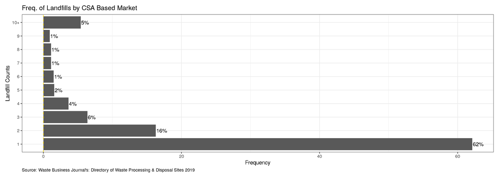

### Cross tabulation of firms

Now we will do a cross tabulation of number of vertically and non-vertically integrated firms per market. Let’s first look at the two different ways we determined which firm is vertically integrated and how correlated they are. The first way we identified vertically integrated firms was through key words such as “Town”, “City”, “County” or “Village” in their operating code name. The other way we identified vertically integrated firms is through the a variable “Operation” that classified firms as public or private. We see the correlation between these two measures is 0.85.

Proportions of Vertically Integrated and Non-Vertically Integrated Firms

|  | Non-Vertically 0 | Non-Vertically 1 | Non-Vertically 2 | Non-Vertically 3 | Non-Vertically 4 | Non-Vertically 5 | Non-Vertically 6 | Non-Vertically 7 | Non-Vertically 8 | Non-Vertically 9 | Non-Vertically 10+ | Non-Vertically Sum |
| --- | --- | --- | --- | --- | --- | --- | --- | --- | --- | --- | --- | --- |
| **Vertically** |  |  |  |  |  |  |  |  |  |  |  |  |
| 0 | 0 | 24 | 5 | 1 | 1 | 0 | 0 | 0 | 0 | 0 | 0 | 31 |
| 1 | 38 | 8 | 2 | 1 | 0 | 1 | 0 | 0 | 0 | 0 | 0 | 51 |
| 2 | 3 | 2 | 1 | 1 | 0 | 0 | 0 | 0 | 0 | 0 | 0 | 7 |
| 3 | 1 | 0 | 0 | 0 | 0 | 0 | 0 | 0 | 0 | 0 | 0 | 3 |
| 4 | 0 | 0 | 0 | 0 | 0 | 0 | 0 | 0 | 0 | 0 | 0 | 1 |
| 5 | 0 | 0 | 0 | 0 | 0 | 0 | 0 | 0 | 0 | 0 | 0 | 1 |
| 6 | 0 | 0 | 0 | 0 | 0 | 0 | 0 | 0 | 0 | 0 | 0 | 1 |
| 7 | 0 | 0 | 0 | 0 | 0 | 0 | 0 | 0 | 0 | 0 | 0 | 1 |
| 8 | 0 | 0 | 0 | 0 | 0 | 0 | 0 | 0 | 0 | 0 | 0 | 0 |
| 9 | 0 | 0 | 0 | 0 | 0 | 0 | 0 | 0 | 0 | 0 | 0 | 1 |
| 10+ | 0 | 0 | 0 | 0 | 0 | 0 | 0 | 0 | 0 | 0 | 1 | 2 |
| Sum | 43 | 36 | 9 | 4 | 2 | 2 | 1 | 1 | 0 | 0 | 3 | 100 |